# ERA Yield Stability

2025-04-02

In this vignette we will explore how to plot and calculate absolute and relative outcome stability.

## Access the data

First we access the compiled ERA dataset included with the ERA package.

```r
knitr::kable(head(ERAg::ERA.Compiled[,1:8], 5))
```

| Index | Code | Author | Date | Journal | DOI | Elevation | Country |
| --- | --- | --- | --- | --- | --- | --- | --- |
| 1 | NN0001 | Bationo A | 1997 | NUTR CYCL AGROECOSYS | 10.1023/a:;1009784812549 | NA | Mali |
| 5 | NN0001 | Bationo A | 1997 | NUTR CYCL AGROECOSYS | 10.1023/a:;1009784812549 | NA | Mali |
| 9 | NN0001 | Bationo A | 1997 | NUTR CYCL AGROECOSYS | 10.1023/a:;1009784812549 | NA | Mali |
| 13 | NN0001 | Bationo A | 1997 | NUTR CYCL AGROECOSYS | 10.1023/a:;1009784812549 | NA | Mali |
| 17 | NN0001 | Bationo A | 1997 | NUTR CYCL AGROECOSYS | 10.1023/a:;1009784812549 | NA | Mali |

Our analyses of outcome stability are inspired and based on the publication *A global meta-analysis of yield stability in organic and conservation agriculture* by [Knapp *et al.* 2018](https://doi.org/10.1038/s41467-018-05956-1). As such we will be exploring the outcome subindicator crop yield in this vignette, which is a data rich vein in ERA.

## Rename higher level concepts

Many functions in the ERA package have been designed work with standardized column names for the higher level concepts of **practice**, **outcome** and **product** (or experimental units) found in the ERA organizational hierarchy.

We can view the subordinates of these high level concepts by accessing the internal datasets `PracticeCodes`, `OutcomesCodes` and `EUCodes`.

```r
knitr::kable(head(PracticeCodes[,1:6], 5))
```

| Code | Theme | Theme.Code | Practice | Practice.Code | Subpractice |
| --- | --- | --- | --- | --- | --- |
| a1 | Agroforestry | Agroforestry | FMNR | FMNR | Farmer Managed Natural Regeneration |
| a3 | Agroforestry | Agroforestry | Alleycropping | Al | Alleycropping (N fixing) |
| a4 | Agroforestry | Agroforestry | Alleycropping | Al | Alleycropping (Non N fixing) |
| a4.1 | Agroforestry | Agroforestry | Alleycropping | Al | Alleycropping (Mixed) |
| a14 | Agroforestry | Agroforestry | Alleycropping | Al | Alleycropping (Unspecified) |

Alternatively the organization of higher level concepts can also be viewed in the `ERAConcepts` list.

```r
ERAg::ERAConcepts
```

```
#> $Prac.Levels
#>         Choice Choice.Code      Prac           Base
#>         <char>      <char>    <char>         <char>
#> 1: Subpractice           S SubPrName SubPrName.Base
#> 2:    Practice           P    PrName    PrName.Base
#>
#> $Out.Levels
#>          Choice Choice.Code           Out
#>          <char>      <char>        <char>
#> 1: Subindicator          SI    Out.SubInd
#> 2:    Indicator           I       Out.Ind
#> 3:    Subpillar          SP Out.SubPillar
#> 4:       Pillar           P    Out.Pillar
#>
#> $Prod.Levels
#>     Choice Choice.Code            Prod
#>     <char>      <char>          <char>
#> 1: Product           P  Product.Simple
#> 2: Subtype           S Product.Subtype
#> 3:    Type           T    Product.Type
#>
#> $Agg.Levels
#>         Choice Choice.Code      Agg            Label
#>         <char>      <char>   <char>           <char>
#> 1: Observation           O    Index    No. Locations
#> 2:       Study           S     Code      No. Studies
#> 3:    Location           L Site.Key No. Observations
```

To apply standardized column names we need to select which organizational levels of the three higher level concepts to use using the `StandColName` function. The function help describes how to do this `?StandColNames`.

Crop yield is an outcome in the *subindicator* level of the outcome hierarchy, so we set the `OLevel` parameter to `SI`. In general you will be using the *subindicator* level for stability analyses.

Regarding practices there are a large number of concepts at the *subpractice* level, so let’s aggregate analysis up the *practice* level; we set the `PLevel` parameter to `P`.

The stability analysis does not explicitly consider products so it’s not critical what organization level of prodct we choose; let’s set the `EULevel` parameter to `P`.

```r
StabData<-ERAg::StandColNames(Data=ERAg::ERA.Compiled,
              PLevel="P",
              OLevel="SI",
              EULevel="P"
              )
```

All we have done with the `StandColNames` function is to rename columns, for example the `Out.SubInd` column has been renamed `Outcome`.

To explore outcome x practice stability for specific products or product groups we could subset the dataset on the `products` columns, for example:

```r
StabData<-StabData[Product.Subtype=="Cereals"]
```

## Prepare the data

Next we need to prepare the data for use with the `StabCalc2` function. To do this we use the `PrepareStabData` function which labels multi-year observations (MYO) and calculates means and variances for outcomes within these MYOs. A multi-year observation is a pair of control and experimental treatments, in the same place and study with multiple observations of the same outcomes over time.

By default the `PrepareStabData` function subsets data to the crop yields outcome (code=101), but the `OutCodes` argument can be used to consider other outcomes. We can investigate outcome codes in the `OutcomeCodes` dataset.

```r
data.table(OutcomeCodes)[grep("Crop Yield",Subindicator),list(Subindicator,Code)]
```

```
#>    Subindicator  Code
#>          <char> <num>
#> 1:   Crop Yield   101
```

```r
StabData<-ERAg::PrepareStabData(Data=StabData,OutCodes=101)
```

The stability analysis needs MYOs of at least 3 seasons to generate any statistics and the `StabCalc` function will filter any MYOs that do not meet this minimum data requirement. If you want to increase the thresholds for MYO length then you can filter on the `nryear` field of the `PrepareStabData` output. For example:

```r
StabData<-StabData[nryears>=4]
```

## Plot the data

```r
StabPlots<-ERAgON::ERAStabPlot(Data=StabData,Robust=F,Intercept=F)
```

Each list element contains two elements, these are ggplots of 1) absolute yield variability (`lnVR`) vs. yield (`lnRR`) and 2) relative yield variability (`lnCVR`) vs. yield (`lnRR`).

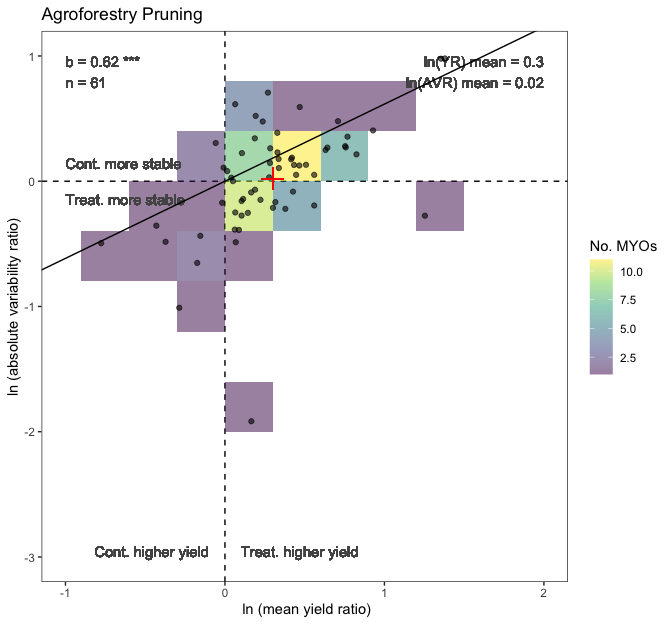

```r
plot(StabPlots$`Crop Yield.Agroforestry Pruning`$lnVR)
```

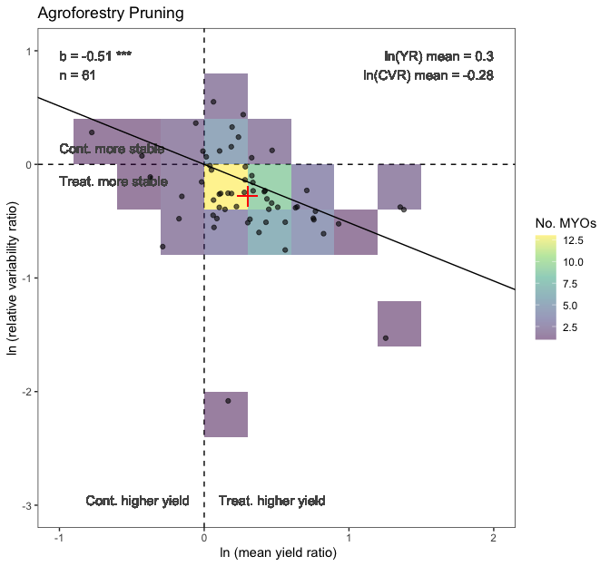

```r
plot(StabPlots$`Crop Yield.Agroforestry Pruning`$lnCVR)
```